# Script 1. Course: Tides in Coastal Bodies

Objective: Get familiar with the Anaconda and Jupyter platforms.

In this session we will lear how to create variables, vectors, and time series to plot

To start we need to import the library necessary to do numerical stuff in python

```python
import numpy as np
```

Now we already told to Jupyter (Python) that we would uses the numpy library to perform numerical calculations

The function np.arange creates a vector using a user defined range of values

```python
x = np.arange(1,100)
print(x)
```

```
[ 1  2  3  4  5  6  7  8  9 10 11 12 13 14 15 16 17 18 19 20 21 22 23 24
 25 26 27 28 29 30 31 32 33 34 35 36 37 38 39 40 41 42 43 44 45 46 47 48
 49 50 51 52 53 54 55 56 57 58 59 60 61 62 63 64 65 66 67 68 69 70 71 72
 73 74 75 76 77 78 79 80 81 82 83 84 85 86 87 88 89 90 91 92 93 94 95 96
 97 98 99]
```

Great! now we have a vector and we can do any mathematic operation with it

```python
#Like a scalar product
a=x*2
```

```python
print(a)
```

```
[  2   4   6   8  10  12  14  16  18  20  22  24  26  28  30  32  34  36
  38  40  42  44  46  48  50  52  54  56  58  60  62  64  66  68  70  72
  74  76  78  80  82  84  86  88  90  92  94  96  98 100 102 104 106 108
 110 112 114 116 118 120 122 124 126 128 130 132 134 136 138 140 142 144
 146 148 150 152 154 156 158 160 162 164 166 168 170 172 174 176 178 180
 182 184 186 188 190 192 194 196 198]
```

```python
#An addition
b=x+3;
print(b)
```

```
[  4   5   6   7   8   9  10  11  12  13  14  15  16  17  18  19  20  21
  22  23  24  25  26  27  28  29  30  31  32  33  34  35  36  37  38  39
  40  41  42  43  44  45  46  47  48  49  50  51  52  53  54  55  56  57
  58  59  60  61  62  63  64  65  66  67  68  69  70  71  72  73  74  75
  76  77  78  79  80  81  82  83  84  85  86  87  88  89  90  91  92  93
  94  95  96  97  98  99 100 101 102]
```

```python
#A substraction
c=x-1
print(c)
```

```
[ 0  1  2  3  4  5  6  7  8  9 10 11 12 13 14 15 16 17 18 19 20 21 22 23
 24 25 26 27 28 29 30 31 32 33 34 35 36 37 38 39 40 41 42 43 44 45 46 47
 48 49 50 51 52 53 54 55 56 57 58 59 60 61 62 63 64 65 66 67 68 69 70 71
 72 73 74 75 76 77 78 79 80 81 82 83 84 85 86 87 88 89 90 91 92 93 94 95
 96 97 98]
```

Lets try a product with two vectors

```python
y=np.arange(10,1000,10)#Note how now I added a third number in the argument; that is to specify an interval
print(y)
```

```
[ 10  20  30  40  50  60  70  80  90 100 110 120 130 140 150 160 170 180
 190 200 210 220 230 240 250 260 270 280 290 300 310 320 330 340 350 360
 370 380 390 400 410 420 430 440 450 460 470 480 490 500 510 520 530 540
 550 560 570 580 590 600 610 620 630 640 650 660 670 680 690 700 710 720
 730 740 750 760 770 780 790 800 810 820 830 840 850 860 870 880 890 900
 910 920 930 940 950 960 970 980 990]
```

```python
z=x*y
print(z)
```

```
[   10    40    90   160   250   360   490   640   810  1000  1210  1440
  1690  1960  2250  2560  2890  3240  3610  4000  4410  4840  5290  5760
  6250  6760  7290  7840  8410  9000  9610 10240 10890 11560 12250 12960
 13690 14440 15210 16000 16810 17640 18490 19360 20250 21160 22090 23040
 24010 25000 26010 27040 28090 29160 30250 31360 32490 33640 34810 36000
 37210 38440 39690 40960 42250 43560 44890 46240 47610 49000 50410 51840
 53290 54760 56250 57760 59290 60840 62410 64000 65610 67240 68890 70560
 72250 73960 75690 77440 79210 81000 82810 84640 86490 88360 90250 92160
 94090 96040 98010]
```

Now that we now how to make a vector lets calculate the sine for a vector of "time (in radians)"

```python
t=np.arange(0,2*np.pi)
```

```python
s=np.sin(t)
```

I need an extra library to make plots and is matplotlib

```python
import matplotlib.pyplot as plt
```

Now we make the plot of the sine

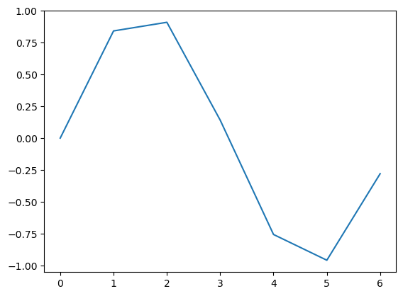

```python
plt.plot(t,s)
```

Congratulations!!! you made your first plot figure in python. Note how the curve is to coarse; to make a smooth curve we need to make a finer interval when defining the "time" vector. Lets do it

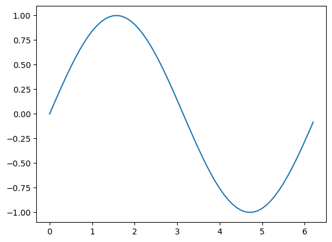

```python
t=np.arange(0,2*np.pi,0.1)
s=np.sin(t)

plt.plot(t,s)
```

Now lets do a serious bussines that will help us a lot for the next sessions. Lets make a sine time series with a period of 12 hours for a month

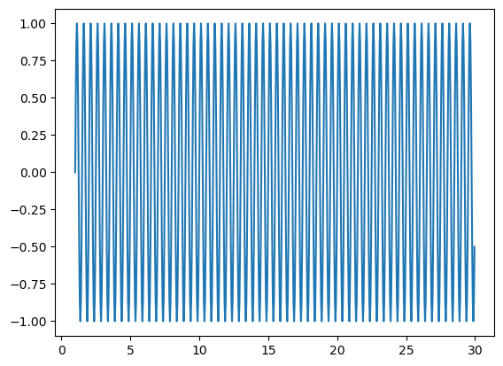

```python
t=np.arange(1,30,1/24)#Im creating a vector of time from day 1 to day 30 with a time inteval of 1/24 days (1 hour)
omega=2*np.pi/(12/24)#I define a frequency for my sine function. This concept will be reviewed in the next session
n=np.sin(omega*t)

plt.plot(t,n)
```

Great!! I think that is it for this session.

Some excercises that you may do to keep practicing

Play with the frequency (omega) variable and pay attention and how the plot change: how many "crests" and "drough" you see?

What happen if you change the interval?

what happen if we add a phaselag of pi/2 to the sine function?